# Human lung integration

Lukas Simon

2022-09-13

This tutorial will be demonstrate the use of scvi-tools for integrating scRNA-seq data sets.

You will need both Python and R installed. [Here](https://urldefense.com/v3/__https://docs.anaconda.com/anaconda/install/__;!!BuQPrrmRaQ!gDSD64UFmRVfJjFbkMj33Lx4swbb-s--Kv5KuqRnD9tOeYQFtbO_DactNEkl_NnH9pVJUA3wMX-fKctlEvAFJw$) you will find more information on how to install Python.

Please use [this](https://docs.google.com/document/d/1Z6qCGBS_rEYA8LttvjE5MJh2uIGAYc_Ti7C_CCPPkEM/edit) document to post code for specific questions.

While scvi-tools is originally written in Python there exists a nice [R wrapper implementation](https://urldefense.com/v3/__https://docs.scvi-tools.org/en/0.7.0/user_guide/notebooks/scvi_in_R.html__;!!BuQPrrmRaQ!gDSD64UFmRVfJjFbkMj33Lx4swbb-s--Kv5KuqRnD9tOeYQFtbO_DactNEkl_NnH9pVJUA3wMX-fKcsJTjY-fA$). Please follow these instructions to install scvi-tools.

Installation of relevant Python packages.

```
pip install scvi-tools
pip install scanpy
```

Installation of relevant R packages.

```
install.packages('Seurat')
install.packages('devtools')
install.packages('BiocManager')
BiocManager::install(c('LoomExperiment', 'SingleCellExperiment'))
devtools::install_github('cellgeni/sceasy')
```

Load R libraries. Please make sure the following libraries are installed.

```r
library(Matrix)
library(reticulate)
library(sceasy)
library(Seurat)
```

Download the following files from [GSE130148](https://urldefense.com/v3/__https://www.ncbi.nlm.nih.gov/geo/query/acc.cgi?acc=GSE130148__;!!BuQPrrmRaQ!gDSD64UFmRVfJjFbkMj33Lx4swbb-s--Kv5KuqRnD9tOeYQFtbO_DactNEkl_NnH9pVJUA3wMX-fKcvjcaozYQ$). This data was first published [here](https://urldefense.com/v3/__https://www.ncbi.nlm.nih.gov/pubmed/31209336__;!!BuQPrrmRaQ!gDSD64UFmRVfJjFbkMj33Lx4swbb-s--Kv5KuqRnD9tOeYQFtbO_DactNEkl_NnH9pVJUA3wMX-fKcuIgm8v-A$).

- GSE130148_raw_counts.csv.gz
- GSE130148_barcodes_cell_types.txt.gz

Once the download is completed load raw count matrix from Schiller paper. Make sure to adjust the paths to your local environment.

```r
schiller_counts <- read.csv(
  gzfile("/Users/lukas/Downloads/GSE130148_raw_counts.csv.gz"),
  row.names = 1
  )
schiller_counts <- as.matrix(schiller_counts)
schiller_counts <- as(schiller_counts, "sparseMatrix")

schiller_celltypes <- read.delim(
  gzfile("/Users/lukas/Downloads/GSE130148_barcodes_cell_types.txt.gz"),
  row.names = 1
  )
```

Download the following files from [GSE128033](https://urldefense.com/v3/__https://www.ncbi.nlm.nih.gov/geo/query/acc.cgi?acc=GSE128033__;!!BuQPrrmRaQ!gDSD64UFmRVfJjFbkMj33Lx4swbb-s--Kv5KuqRnD9tOeYQFtbO_DactNEkl_NnH9pVJUA3wMX-fKcvWsPvYuw$). This data was first published [here](https://urldefense.com/v3/__https://www.ncbi.nlm.nih.gov/pubmed/31221805__;!!BuQPrrmRaQ!gDSD64UFmRVfJjFbkMj33Lx4swbb-s--Kv5KuqRnD9tOeYQFtbO_DactNEkl_NnH9pVJUA3wMX-fKcvXs2e22Q$).

- GSM3660641_SC14NOR_matrix.mtx.gz
- GSM3660641_SC14NOR_genes.tsv.gz
- GSM3660641_SC14NOR_barcodes.tsv.gz

Once the download is completed load raw count matrix from Lafyatis paper. Make sure to adjust the paths to your local environment.

```r
morse_counts <- readMM(
  gzfile("/Users/lukas/Downloads/GSM3660641_SC14NOR_matrix.mtx.gz")
  )
genes <- read.delim(
  gzfile("/Users/lukas/Downloads/GSM3660641_SC14NOR_genes.tsv.gz"),
  header = F
)

cells <- scan(
  gzfile("/Users/lukas/Downloads/GSM3660641_SC14NOR_barcodes.tsv.gz"),
  what = character(), sep = "\n")
rownames(morse_counts) <- genes$V2
colnames(morse_counts) <- cells
```

Create Seurat object for Schiller data. For practicality, we will down sample the data to cells from sample ‘ASK440’ only.

```r
schiller <- CreateSeuratObject(counts = schiller_counts,
                               meta.data = schiller_celltypes)
schiller <- schiller[, schiller@meta.data$orig.ident == "ASK440"]
schiller
```

```
## An object of class Seurat
## 16327 features across 3314 samples within 1 assay
## Active assay: RNA (16327 features, 0 variable features)
```

Create Seurat object for Lafyatis data.

```r
morse <- CreateSeuratObject(counts = morse_counts, min.features = 200)
morse
```

```
## An object of class Seurat
## 33694 features across 970 samples within 1 assay
## Active assay: RNA (33694 features, 0 variable features)
```

Concatenate both Seurat objects.

```r
merged <- merge(schiller, y = morse,
                add.cell.ids = c("Schiller", "Morse"),
                project = "lung_integration")
merged@meta.data$batch <- "Schiller"
merged@meta.data$batch[grep("Morse", rownames(merged@meta.data))] <- "Morse"

merged@assays$RNA@counts <- as.sparse(merged@assays$RNA@counts)
```

Define variable features to be used during integration.

```r
seu_list <- list(schiller, morse)
features <- unique(SelectIntegrationFeatures(object.list = seu_list, nfeatures = 3000, verbose = F))
integrate_this <- merged[features]
```

Run dimension reduction without integration.

```r
merged <- NormalizeData(merged, verbose = F)
merged <- ScaleData(merged, verbose = F)
merged <- RunPCA(merged, features = features, verbose = F)
merged <- RunUMAP(merged, dims = 1:20)
```

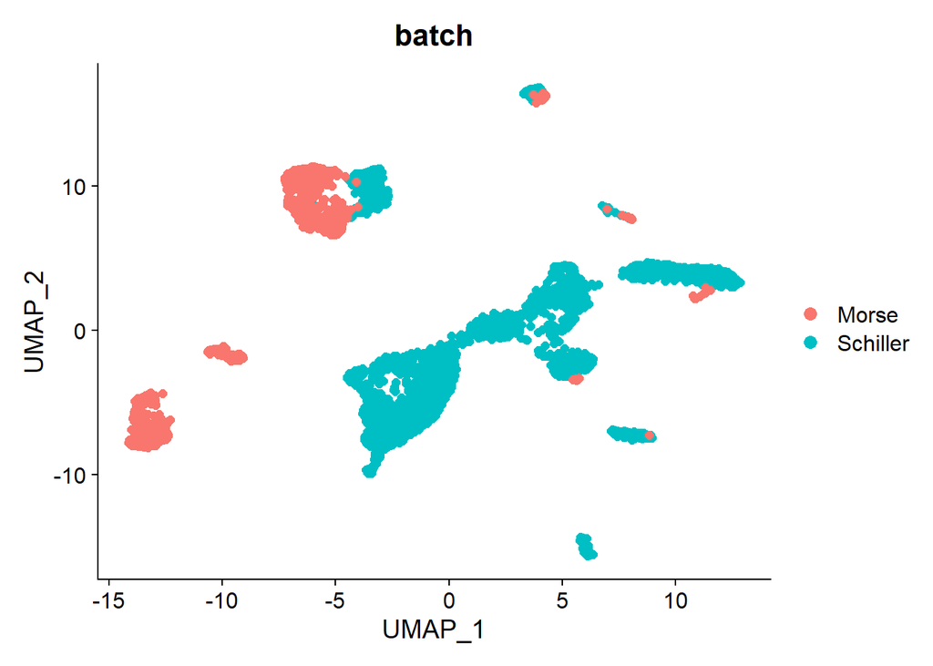

```r
DimPlot(merged, reduction = "umap", group.by = "batch", pt.size=2)
```

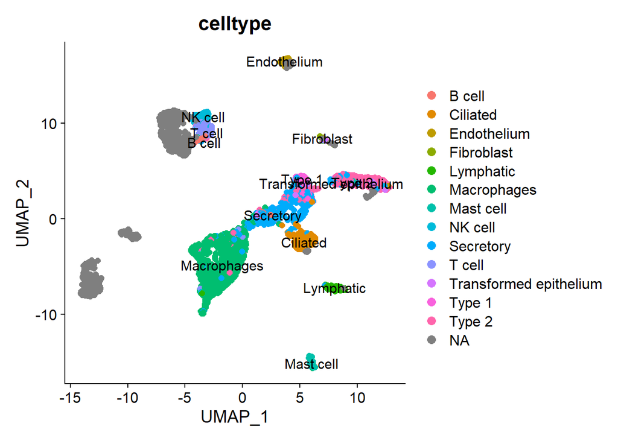

```r
DimPlot(merged, reduction = "umap", group.by = "celltype", pt.size=2, label = T)
```

Load Python modules.

```r
sc <- import("scanpy", convert = FALSE)
scvi <- import("scvi", convert = FALSE)
```

Create adata object.

```r
adata <- convertFormat(
  integrate_this,
  from="seurat",
  to="anndata",
  main_layer="counts",
  drop_single_values=FALSE)
```

Define and train scVI model. For practicality the number of training epochs is currently set to 5, which takes about 1min. This is not a realistic value and we recommend to use the default fo 400 epochs.

```r
scvi$model$SCVI$setup_anndata(adata, batch_key = 'batch')
```

```
## None
```

```r
model <- scvi$model$SCVI(adata)

model$train(max_epochs = as.integer(5))
```

```
## None
```

Run dimension reduction on integrated embedding.

```r
latent = model$get_latent_representation()

latent <- as.matrix(latent)
rownames(latent) = colnames(merged)
merged[["scvi"]] <- CreateDimReducObject(embeddings = latent,
                                         key = "scvi_",
                                         assay = DefaultAssay(merged))
```

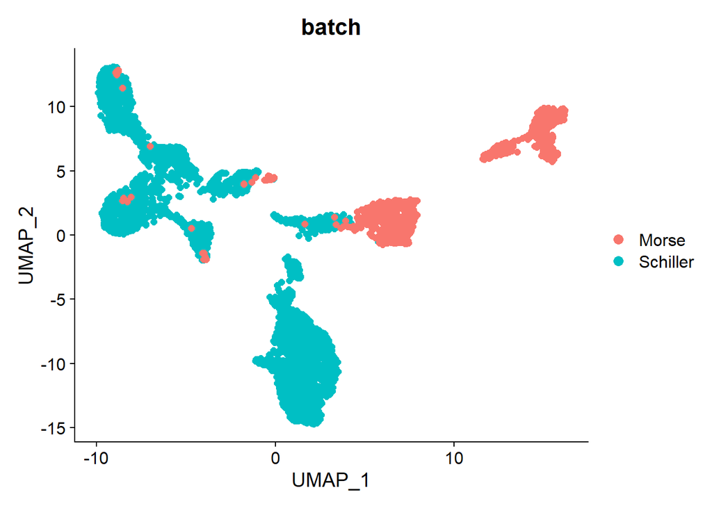

```r
merged <- RunUMAP(merged, dims = 1:10, reduction = "scvi",
                  n.components = 2,
                  verbose = F)

DimPlot(merged, reduction = "umap", group.by = "batch", pt.size=2)
```

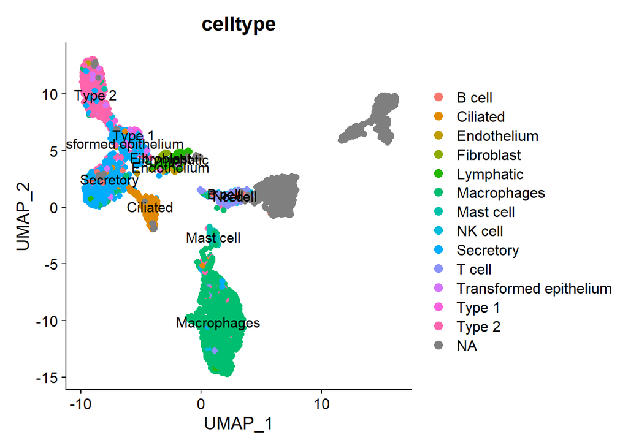

```r
DimPlot(merged, reduction = "umap", group.by = "celltype", pt.size=2, label = T)
```